# Getting Started with stablr

## What is STABL?

STABL (Stability-based Thresholding and Aggregation for Biomarker discovery via LASSO) is a bootstrap-based method for reliable sparse feature selection in high-dimensional datasets. It runs many bootstrap resamples of a penalised learner, computes empirical selection probabilities for each feature, and controls the false-discovery proportion (FDP) by comparing real features against artificial decoys.

The `stablr` package provides a pure-R implementation with full `glmnet`-ecosystem compatibility.

**Core idea in one sentence:** a feature is considered a reliable biomarker if it is selected by the sparse learner *consistently* across many bootstrap resamples, and its selection frequency is substantially higher than what randomly permuted noise features achieve.

## Installation

```r
# From the repository root after cloning:
devtools::install("r-pkg/stablr")
```

```r
library(stablr)
```

## Learning objectives

By the end of this vignette you will be able to:

1. Build a penalty grid with `auto_lambda_grid()` and understand why it matters.
2. Fit a STABL model with `stabl_fit()` and read the printed summary.
3. Extract selected features (`get_support()`) and ranked stability scores (`get_importances()`).
4. Interpret a stability-path plot and an FDR graph.
5. Switch between lasso, adaptive lasso, and elastic-net base learners.

## 1. Binary classification

### Simulated data

We generate a 150-sample x 30-feature dataset. Five features (F1-F5) carry a true signal; the remaining 25 are pure noise. Because we know the ground truth, we can verify that STABL recovers exactly those five features — making this a useful sanity check before applying the method to real data.

```r
n <- 150; p <- 30; n_signal <- 5
X_bin <- matrix(rnorm(n * p), nrow = n,
                dimnames = list(paste0("s", seq_len(n)),
                                paste0("F", seq_len(p))))

# True signal in the first 5 features
beta_bin       <- c(rep(1.5, n_signal), rep(0, p - n_signal))
log_odds       <- X_bin %*% beta_bin
y_bin          <- rbinom(n, size = 1, prob = plogis(log_odds))
names(y_bin)   <- rownames(X_bin)
table(y_bin)
```

```
#> y_bin
#>  0  1
#> 75 75
```

The `table()` output shows the class balance of the outcome. A roughly 50/50 split is ideal; large imbalances can affect how the lasso selects features.

### Fitting STABL

**Step 1 — build a penalty grid.** `auto_lambda_grid()` uses `glmnet` to find the data-dependent range of lambda values and returns a two-column data frame with columns `lambda` and `alpha`. Every row becomes one (lambda, alpha) configuration evaluated during bootstrapping.

**Step 2 — run the bootstrap loop.** `stabl_fit()` resamples the data `n_bootstraps` times, fits the penalised learner at each (lambda, alpha) point, and records which features are selected. Key arguments:

| Argument | What it does |
| --- | --- |
| `family` | Passed to `glmnet`; `"binomial"` for 0/1 outcome, `"gaussian"` for continuous. |
| `n_bootstraps` | Number of bootstrap resamples. 100 is fine for exploration; use 500+ for final results. |
| `artificial_type` | `"random_permutation"` adds column-permuted decoys; `"knockoff"` uses model-X knockoffs for stronger FDP control. |
| `random_state` | Integer seed for full reproducibility. |

We use `n_bootstraps = 100` here for a vignette-friendly runtime.

```r
lambda_bin <- auto_lambda_grid(X_bin, y_bin, family = "binomial", n_lambda = 20)

fit_bin <- stabl_fit(
  x               = X_bin,
  y               = y_bin,
  lambda_grid     = lambda_bin,
  family          = "binomial",
  n_bootstraps    = 100L,
  artificial_type = "random_permutation",
  random_state    = 42L
)

fit_bin
```

```
#> <stabl_fit>
#>   Features in:      30
#>   Features selected: 5
#>   Min FDP+:         0.2
#>   FDP+ threshold:   0.85
#>   Artificial:       random_permutation
```

**Reading the printed summary** — the output reports three key numbers:

- **Stability threshold** — the minimum selection frequency a feature must reach to be called a biomarker (e.g. `0.7` means selected in >= 70% of bootstraps).
- **n selected** — features passing the threshold; for our 5-signal data you expect a small number close to 5.
- **FDP estimate** — estimated upper bound on the false-discovery proportion among selected features; values well below 0.05 indicate reliable selection.

### Inspecting results

```r
# Features selected at the STABL threshold
get_support(fit_bin)
```

```
#>    F1    F2    F3    F4    F5    F6    F7    F8    F9   F10   F11   F12   F13
#>  TRUE  TRUE  TRUE  TRUE  TRUE FALSE FALSE FALSE FALSE FALSE FALSE FALSE FALSE
#>   F14   F15   F16   F17   F18   F19   F20   F21   F22   F23   F24   F25   F26
#> FALSE FALSE FALSE FALSE FALSE FALSE FALSE FALSE FALSE FALSE FALSE FALSE FALSE
#>   F27   F28   F29   F30
#> FALSE FALSE FALSE FALSE
```

```r
# Stability scores for all features (sorted descending)
head(get_importances(fit_bin), 10)
```

```
#>   F1   F2   F3   F4   F5   F6   F7   F8   F9  F10
#> 0.99 1.00 0.98 1.00 1.00 0.76 0.83 0.58 0.59 0.74
```

### Visualisation

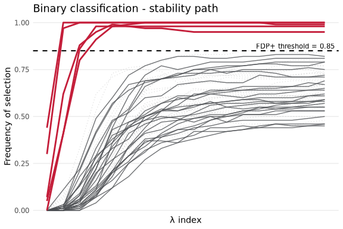

```r
plot_stabl_path(fit_bin, title = "Binary classification - stability path")
```

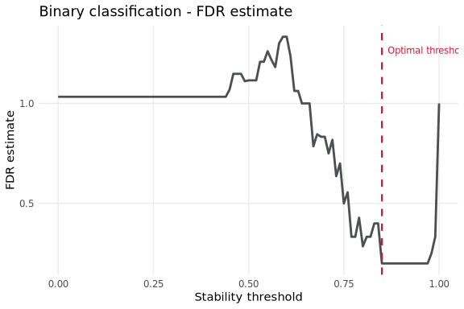

```r
plot_fdr_graph(fit_bin, title = "Binary classification - FDR estimate")
```

## 2. Regression

### Simulated data

We reuse the same 150 x 30 dimensions but draw an independent feature matrix and generate a *continuous* outcome (linear combination of F1-F5 plus Gaussian noise). The only change to the fitting workflow is `family = "gaussian"`.

```r
X_reg <- matrix(rnorm(n * p), nrow = n,
                dimnames = list(paste0("s", seq_len(n)),
                                paste0("F", seq_len(p))))
beta_reg     <- c(rep(2, n_signal), rep(0, p - n_signal))
y_reg        <- X_reg %*% beta_reg + rnorm(n, sd = 1)
names(y_reg) <- rownames(X_reg)
```

### Fitting STABL

```r
lambda_reg <- auto_lambda_grid(X_reg, y_reg, family = "gaussian", n_lambda = 20)

fit_reg <- stabl_fit(
  x               = X_reg,
  y               = y_reg,
  lambda_grid     = lambda_reg,
  family          = "gaussian",
  n_bootstraps    = 100L,
  artificial_type = "random_permutation",
  random_state    = 42L
)

fit_reg
```

```
#> <stabl_fit>
#>   Features in:      30
#>   Features selected: 8
#>   Min FDP+:         0.375
#>   FDP+ threshold:   0.99
#>   Artificial:       random_permutation
```

### Results

```r
get_support(fit_reg)
```

```
#>    F1    F2    F3    F4    F5    F6    F7    F8    F9   F10   F11   F12   F13
#>  TRUE  TRUE  TRUE  TRUE  TRUE FALSE FALSE  TRUE FALSE FALSE FALSE FALSE FALSE
#>   F14   F15   F16   F17   F18   F19   F20   F21   F22   F23   F24   F25   F26
#>  TRUE FALSE FALSE FALSE FALSE FALSE  TRUE FALSE FALSE FALSE FALSE FALSE FALSE
#>   F27   F28   F29   F30
#> FALSE FALSE FALSE FALSE
```

```r
head(get_importances(fit_reg), 10)
```

```
#>   F1   F2   F3   F4   F5   F6   F7   F8   F9  F10
#> 1.00 1.00 1.00 1.00 1.00 0.98 0.97 1.00 0.98 0.98
```

### Visualisation

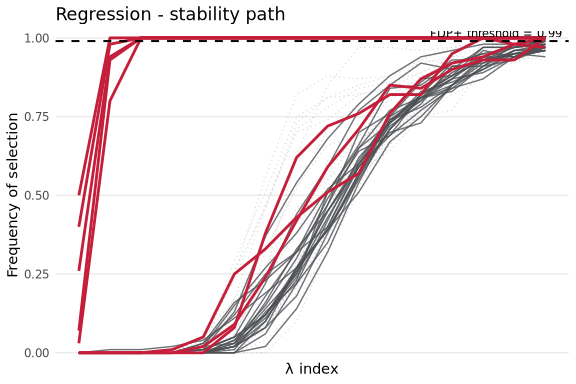

```r
plot_stabl_path(fit_reg, title = "Regression - stability path")
```

## 3. Learner variants

### Adaptive lasso

The adaptive lasso re-weights the L1 penalty so that features with small coefficients in a preliminary ridge fit are penalised more heavily. This sharpens the stability contrast: true signal features accumulate higher selection frequencies while noise features are pushed further toward zero.

**When to use it:** prefer adaptive lasso when you expect a sparse true signal and want a tighter biomarker list with fewer borderline features.

**What to expect:** `get_support(fit_ada)` should return F1-F5, and `get_importances()` will typically show higher scores for true features compared to plain lasso.

```r
lambda_ada <- auto_lambda_grid(X_bin, y_bin, family = "binomial", n_lambda = 20)

fit_ada <- stabl_fit(
  x               = X_bin,
  y               = y_bin,
  lambda_grid     = lambda_ada,
  base_learner    = "adaptive_lasso",
  family          = "binomial",
  n_bootstraps    = 100L,
  artificial_type = "random_permutation",
  random_state    = 42L
)

get_support(fit_ada)
```

```
#>    F1    F2    F3    F4    F5    F6    F7    F8    F9   F10   F11   F12   F13
#>  TRUE  TRUE  TRUE  TRUE  TRUE FALSE FALSE FALSE FALSE FALSE FALSE FALSE FALSE
#>   F14   F15   F16   F17   F18   F19   F20   F21   F22   F23   F24   F25   F26
#> FALSE FALSE FALSE FALSE FALSE FALSE FALSE FALSE FALSE FALSE FALSE FALSE FALSE
#>   F27   F28   F29   F30
#> FALSE FALSE FALSE FALSE
```

### Elastic net

Elastic net interpolates between lasso (alpha = 1) and ridge (alpha = 0). The L2 component encourages correlated features to be selected together, which is useful when biomarkers form functional modules (e.g. co-expressed genes).

Passing multiple `l1_ratio` values to `auto_lambda_grid()` makes STABL sweep the (lambda, alpha) grid jointly, exploring both the sparsity level and the L1/L2 mix in every bootstrap.

**When to use it:** prefer elastic net over plain lasso when features are highly correlated and you want to avoid arbitrarily picking one representative from a correlated group.

```r
lambda_en <- auto_lambda_grid(
  X_bin, y_bin,
  family = "binomial", n_lambda = 10,
  l1_ratio = c(0.5, 0.9)
)

fit_en <- stabl_fit(
  x               = X_bin,
  y               = y_bin,
  lambda_grid     = lambda_en,
  base_learner    = "elastic_net",
  family          = "binomial",
  n_bootstraps    = 100L,
  artificial_type = "random_permutation",
  random_state    = 42L
)

get_support(fit_en)
```

```
#>    F1    F2    F3    F4    F5    F6    F7    F8    F9   F10   F11   F12   F13
#>  TRUE  TRUE  TRUE  TRUE  TRUE FALSE  TRUE FALSE FALSE FALSE FALSE FALSE FALSE
#>   F14   F15   F16   F17   F18   F19   F20   F21   F22   F23   F24   F25   F26
#> FALSE FALSE FALSE FALSE FALSE FALSE FALSE FALSE FALSE FALSE FALSE FALSE FALSE
#>   F27   F28   F29   F30
#> FALSE FALSE FALSE FALSE
```

## Next steps

- See `vignette("stablr-multiomic")` for multi-omic integration with early and late fusion on a real Onset of Labor dataset.
- See `?stabl_multiomic_cv` for grouped cross-validation workflows.
- See `?save_stabl_results` for exporting scores, plots, and selected-feature tables to disk.